# TidyTuesday - Bechdel Test

## TidyTuesday - 9 March 2021

The dataset is loaded from the tidytuesdayR package

```r
library(tidytuesdayR)
library(summarytools)
library(tidyverse)
library(dplyr)

# Load data
tuesdata <- tidytuesdayR::tt_load('2021-03-09')
```

```
--- Compiling #TidyTuesday Information for 2021-03-09 ----
--- There are 2 files available ---
--- Starting Download ---
```

```
--- Download complete ---
```

```r
tuesdata <- tidytuesdayR::tt_load(2021, week = 11)
```

```
--- Compiling #TidyTuesday Information for 2021-03-09 ----
--- There are 2 files available ---
--- Starting Download ---
```

```
--- Download complete ---
```

```r
bechdel <- tuesdata$movies

head(bechdel)
```

| year | imdb | title | test | clean_test | binary | budget | domgross | intgross | code | budget_2013 | domgross_2013 | intgross_2013 | period_code | decade_code | imdb_id | plot | rated | response | language | country | writer | metascore | imdb_rating | director | released | actors | genre | awards | runtime | … |
| --- | --- | --- | --- | --- | --- | --- | --- | --- | --- | --- | --- | --- | --- | --- | --- | --- | --- | --- | --- | --- | --- | --- | --- | --- | --- | --- | --- | --- | --- | --- |
| 2013 | tt1711425 | 21 &amp; Over | notalk | notalk | FAIL | 1.30e+07 | 25682380 | 42195766 | 2013FAIL | 13000000 | 25682380 | 42195766 | 1 | 1 | 1711425 | NA | NA | NA | NA | NA | NA | NA | NA | NA | NA | NA | NA | NA | NA | … |
| 2012 | tt1343727 | Dredd 3D | ok-disagree | ok | PASS | 4.50e+07 | 13414714 | 40868994 | 2012PASS | 45658735 | 13611086 | 41467257 | 1 | 1 | 1343727 | NA | NA | NA | NA | NA | NA | NA | NA | NA | NA | NA | NA | NA | NA | … |
| 2013 | tt2024544 | 12 Years a Slave | notalk-disagree | notalk | FAIL | 2.00e+07 | 53107035 | 158607035 | 2013FAIL | 20000000 | 53107035 | 158607035 | 1 | 1 | 2024544 | In the antebellum United States, Solomon Northup, a free black man from upstate New York, is abducted and sold into slavery. | R | TRUE | English | USA, UK | John Ridley (screenplay), Solomon Northup (based on "Twelve Years a Slave" by) | 97 | 8.3 | Steve McQueen | 08 Nov 2013 | Chiwetel Ejiofor, Dwight Henry, Dickie Gravois, Bryan Batt | Biography, Drama, History | Won 3 Oscars. Another 131 wins & 137 nominations. | 134 min | … |
| 2013 | tt1272878 | 2 Guns | notalk | notalk | FAIL | 6.10e+07 | 75612460 | 132493015 | 2013FAIL | 61000000 | 75612460 | 132493015 | 1 | 1 | 1272878 | A DEA agent and a naval intelligence officer find themselves on the run after a botched attempt to infiltrate a drug cartel. While fleeing, they learn the secret of their shaky alliance: Neither knew … | R | TRUE | English, Spanish | USA | Blake Masters (screenplay), Steven Grant (based on the Boom! Studios graphic novels by) | 55 | 6.8 | Baltasar Kormákur | 02 Aug 2013 | Denzel Washington, Mark Wahlberg, Paula Patton, Edward James Olmos | Action, Comedy, Crime | 1 win. | 109 min | … |
| 2013 | tt0453562 | 42 | men | men | FAIL | 4.00e+07 | 95020213 | 95020213 | 2013FAIL | 40000000 | 95020213 | 95020213 | 1 | 1 | 0453562 | The life story of Jackie Robinson and his history-making signing with the Brooklyn Dodgers under the guidance of team executive Branch Rickey. | PG-13 | TRUE | English | USA | Brian Helgeland | 62 | 7.6 | Brian Helgeland | 12 Apr 2013 | Chadwick Boseman, Harrison Ford, Nicole Beharie, Christopher Meloni | Biography, Drama, Sport | 3 wins & 13 nominations. | 128 min | … |
| 2013 | tt1335975 | 47 Ronin | men | men | FAIL | 2.25e+08 | 38362475 | 145803842 | 2013FAIL | 225000000 | 38362475 | 145803842 | 1 | 1 | 1335975 | A band of samurai set out to avenge the death and dishonor of their master at the hands of a ruthless shogun. | PG-13 | TRUE | English, Japanese | USA | Chris Morgan (screenplay), Hossein Amini (screenplay), Chris Morgan (screen story by), Walter Hamada (screen story by) | 29 | 6.6 | Carl Rinsch | 25 Dec 2013 | Keanu Reeves, Hiroyuki Sanada, Ko Shibasaki, Tadanobu Asano | Action, Adventure, Fantasy | 1 nomination. | 118 min | … |

```r
NA
```

### The dataset

```r
library(summarytools)

view(dfSummary(bechdel), method = 'render')
```

Data Frame Summary

bechdel

**Dimensions**: 1794 x 34  
**Duplicates**: 0

| **No** | **Variable** | **Stats / Values** | **Freqs (% of Valid)** | **Graph** | **Valid** | **Missing** |
| --- | --- | --- | --- | --- | --- | --- |
| 1 | year [numeric] | Mean (sd) : 2002.6 (9) min < med < max: 1970 < 2005 < 2013 IQR (CV) : 11 (0) | 44 distinct values |  | 1794 (100.0%) | 0 (0.0%) |
| 2 | imdb [character] | 1. tt00293564 2. tt0035423 3. tt0065466 4. tt0067065 5. tt0067116 6. tt0067741 7. tt0067800 8. tt0067992 9. tt0068156 10. tt0068646 [ 1784 others ] | 1 ( 0.1% ) 1 ( 0.1% ) 1 ( 0.1% ) 1 ( 0.1% ) 1 ( 0.1% ) 1 ( 0.1% ) 1 ( 0.1% ) 1 ( 0.1% ) 1 ( 0.1% ) 1 ( 0.1% ) 1784 ( 99.4% ) |  | 1794 (100.0%) | 0 (0.0%) |
| 3 | title [character] | 1. Pride and Prejudice 2. Assault on Precinct 13 3. Beautiful Creatures 4. Black Christmas 5. Carrie 6. Conan the Barbarian 7. Dawn of the Dead 8. Day of the Dead 9. Dune 10. Friday the 13th [ 1758 ot… | 3 ( 0.2% ) 2 ( 0.1% ) 2 ( 0.1% ) 2 ( 0.1% ) 2 ( 0.1% ) 2 ( 0.1% ) 2 ( 0.1% ) 2 ( 0.1% ) 2 ( 0.1% ) 2 ( 0.1% ) 1773 ( 98.8% ) |  | 1794 (100.0%) | 0 (0.0%) |
| 4 | test [character] | 1. dubious 2. dubious-disagree 3. men 4. men-disagree 5. notalk 6. notalk-disagree 7. nowomen 8. nowomen-disagree 9. ok 10. ok-disagree | 81 ( 4.5% ) 61 ( 3.4% ) 125 ( 7.0% ) 69 ( 3.8% ) 379 ( 21.1% ) 135 ( 7.5% ) 88 ( 4.9% ) 53 ( 3.0% ) 696 ( 38.8% ) 107 ( 6.0% ) |  | 1794 (100.0%) | 0 (0.0%) |
| 5 | clean_test [character] | 1. dubious 2. men 3. notalk 4. nowomen 5. ok | 142 ( 7.9% ) 194 ( 10.8% ) 514 ( 28.7% ) 141 ( 7.9% ) 803 ( 44.8% ) |  | 1794 (100.0%) | 0 (0.0%) |
| 6 | binary [character] | 1. FAIL 2. PASS | 991 ( 55.2% ) 803 ( 44.8% ) |  | 1794 (100.0%) | 0 (0.0%) |
| 7 | budget [numeric] | Mean (sd) : 44826463 (48186026) min < med < max: 7000 < 2.8e+07 < 4.25e+08 IQR (CV) : 4.8e+07 (1.1) | 272 distinct values |  | 1794 (100.0%) | 0 (0.0%) |
| 8 | domgross [character] | 1. #N/A 2. 38372662 3. 102515793 4. 10324441 5. 16235738 6. 165092266 7. 17142080 8. 176591618 9. 19452138 10. 20040895 [ 1741 others ] | 17 ( 0.9% ) 3 ( 0.2% ) 2 ( 0.1% ) 2 ( 0.1% ) 2 ( 0.1% ) 2 ( 0.1% ) 2 ( 0.1% ) 2 ( 0.1% ) 2 ( 0.1% ) 2 ( 0.1% ) 1758 ( 98.0% ) |  | 1794 (100.0%) | 0 (0.0%) |
| 9 | intgross [character] | 1. #N/A 2. 120918508 3. 1004550114 4. 103452875 5. 109175673 6. 11253821 7. 16235738 8. 18400000 9. 198615996 10. 233170238 [ 1747 others ] | 11 ( 0.6% ) 3 ( 0.2% ) 2 ( 0.1% ) 2 ( 0.1% ) 2 ( 0.1% ) 2 ( 0.1% ) 2 ( 0.1% ) 2 ( 0.1% ) 2 ( 0.1% ) 2 ( 0.1% ) 1764 ( 98.3% ) |  | 1794 (100.0%) | 0 (0.0%) |
| 10 | code [character] | 1. 2009FAIL 2. 2011FAIL 3. 2010FAIL 4. 2010PASS 5. 2005PASS 6. 2011PASS 7. 2013FAIL 8. 2008PASS 9. 2008FAIL 10. 2012FAIL [ 75 others ] | 82 ( 4.6% ) 71 ( 4.0% ) 68 ( 3.8% ) 61 ( 3.4% ) 54 ( 3.0% ) 53 ( 3.0% ) 53 ( 3.0% ) 51 ( 2.8% ) 50 ( 2.8% ) 49 ( 2.7% ) 1202 ( 67.0% ) |  | 1794 (100.0%) | 0 (0.0%) |
| 11 | budget_2013 [numeric] | Mean (sd) : 55464609 (54918636) min < med < max: 8632 < 36995786 < 461435929 IQR (CV) : 62268988 (1) | 1188 distinct values |  | 1794 (100.0%) | 0 (0.0%) |
| 12 | domgross_2013 [character] | 1. #N/A 2. 125520924 3. 100004670 4. 10019987 5. 100242021 6. 100307450 7. 100347776 8. 100674928 9. 101179654 10. 101470202 [ 1766 others ] | 18 ( 1.0% ) 2 ( 0.1% ) 1 ( 0.1% ) 1 ( 0.1% ) 1 ( 0.1% ) 1 ( 0.1% ) 1 ( 0.1% ) 1 ( 0.1% ) 1 ( 0.1% ) 1 ( 0.1% ) 1766 ( 98.4% ) |  | 1794 (100.0%) | 0 (0.0%) |
| 13 | intgross_2013 [character] | 1. #N/A 2. 125520924 3. 1004550114 4. 100507729 5. 10051933 6. 100602327 7. 10063173 8. 100734332 9. 100905781 10. 101076746 [ 1773 others ] | 11 ( 0.6% ) 2 ( 0.1% ) 1 ( 0.1% ) 1 ( 0.1% ) 1 ( 0.1% ) 1 ( 0.1% ) 1 ( 0.1% ) 1 ( 0.1% ) 1 ( 0.1% ) 1 ( 0.1% ) 1773 ( 98.8% ) |  | 1794 (100.0%) | 0 (0.0%) |
| 14 | period_code [numeric] | Mean (sd) : 2.4 (1.2) min < med < max: 1 < 2 < 5 IQR (CV) : 2 (0.5) | 1 : 438 ( 27.1% ) 2 : 488 ( 30.2% ) 3 : 352 ( 21.8% ) 4 : 247 ( 15.3% ) 5 : 90 ( 5.6% ) |  | 1615 (90.0%) | 179 (10.0%) |
| 15 | decade_code [numeric] | Mean (sd) : 1.9 (0.7) min < med < max: 1 < 2 < 3 IQR (CV) : 1 (0.4) | 1 : 438 ( 27.1% ) 2 : 840 ( 52.0% ) 3 : 337 ( 20.9% ) |  | 1615 (90.0%) | 179 (10.0%) |
| 16 | imdb_id [character] | 1. 00293564 2. 0035423 3. 0065466 4. 0067065 5. 0067116 6. 0067741 7. 0067800 8. 0067992 9. 0068156 10. 0068646 [ 1784 others ] | 1 ( 0.1% ) 1 ( 0.1% ) 1 ( 0.1% ) 1 ( 0.1% ) 1 ( 0.1% ) 1 ( 0.1% ) 1 ( 0.1% ) 1 ( 0.1% ) 1 ( 0.1% ) 1 ( 0.1% ) 1784 ( 99.4% ) |  | 1794 (100.0%) | 0 (0.0%) |
| 17 | plot [character] | 1. "21" is the fact-based st 2. "Dude" Lebowski, mistaken 3. 123 elite U.S. soldiers d 4. 15-year-old Oliver Tate h 5. 200 years after her death 6. 28-year-old Kansas Univer 7. 5 years after Pitch Bla… | 1 ( 0.1% ) 1 ( 0.1% ) 1 ( 0.1% ) 1 ( 0.1% ) 1 ( 0.1% ) 1 ( 0.1% ) 1 ( 0.1% ) 1 ( 0.1% ) 1 ( 0.1% ) 1 ( 0.1% ) 1582 ( 99.4% ) |  | 1592 (88.7%) | 202 (11.3%) |
| 18 | rated [character] | 1. G 2. N/A 3. NC-17 4. Not Rated 5. PG 6. PG-13 7. R 8. TV-14 9. TV-PG 10. Unrated 11. X | 36 ( 2.3% ) 10 ( 0.6% ) 7 ( 0.4% ) 15 ( 0.9% ) 257 ( 16.1% ) 565 ( 35.5% ) 691 ( 43.4% ) 1 ( 0.1% ) 1 ( 0.1% ) 5 ( 0.3% ) 4 ( 0.3% ) |  | 1592 (88.7%) | 202 (11.3%) |
| 19 | response [logical] | 1. TRUE | 1592 ( 100.0% ) |  | 1592 (88.7%) | 202 (11.3%) |
| 20 | language [character] | 1. English 2. English, Spanish 3. English, French 4. English, Italian 5. English, Russian 6. English, German 7. English, Japanese 8. English, Mandarin 9. English, German, French 10. English, Cantonese… | 993 ( 62.4% ) 75 ( 4.7% ) 58 ( 3.6% ) 24 ( 1.5% ) 23 ( 1.4% ) 19 ( 1.2% ) 14 ( 0.9% ) 14 ( 0.9% ) 8 ( 0.5% ) 7 ( 0.4% ) 357 ( 22.4% ) |  | 1592 (88.7%) | 202 (11.3%) |
| 21 | country [character] | 1. USA 2. UK, USA 3. USA, Germany 4. USA, UK 5. USA, Canada 6. UK 7. USA, Australia 8. USA, France 9. Germany, USA 10. France, USA [ 186 others ] | 991 ( 62.2% ) 58 ( 3.6% ) 58 ( 3.6% ) 57 ( 3.6% ) 42 ( 2.6% ) 38 ( 2.4% ) 22 ( 1.4% ) 13 ( 0.8% ) 11 ( 0.7% ) 9 ( 0.6% ) 293 ( 18.4% ) |  | 1592 (88.7%) | 202 (11.3%) |
| 22 | writer [character] | 1. Woody Allen 2. Kevin Smith 3. M. Night Shyamalan 4. Andrew Niccol 5. Kurt Wimmer 6. Melissa Rosenberg (screen 7. Mike Leigh 8. Steve Kloves (screenplay) 9. George A. Romero 10. Guy Ritchie [ 1462 o… | 7 ( 0.4% ) 6 ( 0.4% ) 6 ( 0.4% ) 4 ( 0.3% ) 4 ( 0.3% ) 4 ( 0.3% ) 4 ( 0.3% ) 4 ( 0.3% ) 3 ( 0.2% ) 3 ( 0.2% ) 1547 ( 97.2% ) |  | 1592 (88.7%) | 202 (11.3%) |
| 23 | metascore [numeric] | Mean (sd) : 59 (17.2) min < med < max: 11 < 60 < 100 IQR (CV) : 25 (0.3) | 86 distinct values |  | 1416 (78.9%) | 378 (21.1%) |
| 24 | imdb_rating [numeric] | Mean (sd) : 6.8 (1) min < med < max: 2.1 < 6.8 < 9.3 IQR (CV) : 1.2 (0.1) | 65 distinct values |  | 1592 (88.7%) | 202 (11.3%) |
| 25 | director [character] | 1. Steven Spielberg 2. Martin Scorsese 3. Robert Zemeckis 4. Ridley Scott 5. Sam Raimi 6. Steven Soderbergh 7. Tim Burton 8. Joel Schumacher 9. Woody Allen 10. Clint Eastwood [ 881 others ] | 19 ( 1.2% ) 12 ( 0.8% ) 12 ( 0.8% ) 10 ( 0.6% ) 10 ( 0.6% ) 10 ( 0.6% ) 10 ( 0.6% ) 9 ( 0.6% ) 9 ( 0.6% ) 8 ( 0.5% ) 1483 ( 93.2% ) |  | 1592 (88.7%) | 202 (11.3%) |
| 26 | released [character] | 1. 02 Oct 2009 2. 05 Nov 2010 3. 20 Jan 2012 4. 03 Mar 2006 5. 04 Jan 2002 6. 05 Jan 2007 7. 06 Nov 2009 8. 07 Apr 2006 9. 07 Aug 2009 10. 07 Feb 2003 [ 1102 others ] | 5 ( 0.3% ) 5 ( 0.3% ) 5 ( 0.3% ) 4 ( 0.3% ) 4 ( 0.3% ) 4 ( 0.3% ) 4 ( 0.3% ) 4 ( 0.3% ) 4 ( 0.3% ) 4 ( 0.3% ) 1549 ( 97.3% ) |  | 1592 (88.7%) | 202 (11.3%) |
| 27 | actors [character] | 1. William Shatner, Leonard 2. Antonio Banderas, Carla G 3. Patrick Stewart, Jonathan 4. Adam Sandler, Kevin James 5. Chris Hemsworth, Natalie 6. Ian McKellen, Martin Free 7. Mark Hamill, Harrison For… | 4 ( 0.3% ) 3 ( 0.2% ) 3 ( 0.2% ) 2 ( 0.1% ) 2 ( 0.1% ) 2 ( 0.1% ) 2 ( 0.1% ) 2 ( 0.1% ) 2 ( 0.1% ) 2 ( 0.1% ) 1568 ( 98.5% ) |  | 1592 (88.7%) | 202 (11.3%) |
| 28 | genre [character] | 1. Comedy, Drama, Romance 2. Comedy, Drama 3. Drama 4. Action, Adventure, Sci-Fi 5. Comedy 6. Comedy, Romance 7. Animation, Adventure, Com 8. Drama, Romance 9. Action, Adventure, Fantas 10. Action, Cr… | 65 ( 4.1% ) 64 ( 4.0% ) 59 ( 3.7% ) 53 ( 3.3% ) 51 ( 3.2% ) 45 ( 2.8% ) 44 ( 2.8% ) 44 ( 2.8% ) 41 ( 2.6% ) 37 ( 2.3% ) 1089 ( 68.4% ) |  | 1592 (88.7%) | 202 (11.3%) |
| 29 | awards [character] | 1. N/A 2. 1 nomination. 3. 2 nominations. 4. 1 win. 5. 1 win & 2 nominations. 6. 1 win & 1 nomination. 7. 1 win & 3 nominations. 8. 1 win & 4 nominations. 9. 4 nominations. 10. 3 nominations. [ 750 ot… | 104 ( 6.5% ) 73 ( 4.6% ) 55 ( 3.5% ) 34 ( 2.1% ) 33 ( 2.1% ) 28 ( 1.8% ) 28 ( 1.8% ) 25 ( 1.6% ) 24 ( 1.5% ) 22 ( 1.4% ) 1166 ( 73.2% ) |  | 1592 (88.7%) | 202 (11.3%) |
| 30 | runtime [character] | 1. 98 min 2. 100 min 3. 94 min 4. 97 min 5. 93 min 6. 101 min 7. 104 min 8. 103 min 9. 107 min 10. 110 min [ 109 others ] | 52 ( 3.3% ) 47 ( 3.0% ) 41 ( 2.6% ) 41 ( 2.6% ) 40 ( 2.5% ) 39 ( 2.4% ) 39 ( 2.4% ) 38 ( 2.4% ) 38 ( 2.4% ) 35 ( 2.2% ) 1182 ( 74.2% ) |  | 1592 (88.7%) | 202 (11.3%) |
| 31 | type [character] | 1. movie | 1592 ( 100.0% ) |  | 1592 (88.7%) | 202 (11.3%) |
| 32 | poster [character] | 1. N/A 2. http://ia.media-imdb.com/ 3. http://ia.media-imdb.com/ 4. http://ia.media-imdb.com/ 5. http://ia.media-imdb.com/ 6. http://ia.media-imdb.com/ 7. http://ia.media-imdb.com/ 8. http://ia.media-… | 2 ( 0.1% ) 1 ( 0.1% ) 1 ( 0.1% ) 1 ( 0.1% ) 1 ( 0.1% ) 1 ( 0.1% ) 1 ( 0.1% ) 1 ( 0.1% ) 1 ( 0.1% ) 1 ( 0.1% ) 1581 ( 99.3% ) |  | 1592 (88.7%) | 202 (11.3%) |
| 33 | imdb_votes [numeric] | Mean (sd) : 116354 (131897.6) min < med < max: 71 < 70153.5 < 1187486 IQR (CV) : 121852.5 (1.1) | 1588 distinct values |  | 1592 (88.7%) | 202 (11.3%) |
| 34 | error [logical] | All NA's |  |  | 0 (0.0%) | 1794 (100.0%) |

Generated by summarytools 0.9.8 ([R](https://www.r-project.org/) version 4.0.3)  
2021-03-09

```r
NA
```

### Selecting a dataset for analysis

The following variables will be retained for analysis:

- year
- title
- clean_test
- binary
- budget_2013
- domgross_2013
- intgross_2013
- period_code
- decade_code
- rated
- metascore
- imdb_rating
- genre

```r
bechdel_short <- bechdel %>%
  select(year, title, clean_test, binary, budget_2013, domgross_2013, intgross_2013, period_code, decade_code, rated, metascore, imdb_rating, genre)
```

### Investigate `clean_test` variable

- The values: “dubious”, “men”, “notalk” and “nowomen” all represent Bechdel test failures
- “ok” represents a Bechdel test pass
- The variable needs to be converted into a factor with the following order:
  - 1. No women
  - 2. No talk
  - 3. Men
  - 4. Dubious
  - 5. OK

[figure not shown]

```r
ggplot(bechdel_short,
       aes(x = clean_test, fill = binary)) +
  geom_bar()
```

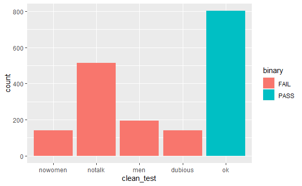

```r
clean_test_levels <- c("nowomen", "notalk",
                       "men", "dubious", "ok")

bechdel_short <- bechdel_short %>%
  mutate(clean_test = factor(clean_test, levels = clean_test_levels))

ggplot(bechdel_short,
       aes(x = clean_test, fill = binary)) +
  geom_bar()
```

### Relationship between clean_test and year

The number of observations significant increases after 1995, so its difficult to tell how the distribution changes by year

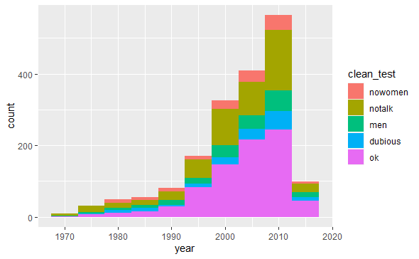

```r
ggplot(bechdel_short, aes(x = year, fill = clean_test)) +
  geom_histogram(binwidth = 5)
```

### Understanding period codes

- Period 1 = 2010-2013 (c. 400 obs)
- Period 2 = 2005-2009 (c. 500 obs)
- Period 3 = 2000-2004 (c. 350 obs)
- Period 4 = 1995-1999 (c. 250 obs)
- Period 5 = 1990-1994 (c. 90 obs)
- Period NA = 1970-1989 (c. 180 obs)

```r
bechdel_short %>%
  select(period_code, year) %>%
  group_by(period_code) %>%
  summarize(min_year = min(year), max_year = max(year), count = n())
```

|  | period_code | min_year | max_year | count |
| --- | --- | --- | --- | --- |
| 1 | 1 | 2010 | 2013 | 438 |
| 2 | 2 | 2005 | 2009 | 488 |
| 3 | 3 | 2000 | 2004 | 352 |
| 4 | 4 | 1995 | 1999 | 247 |
| 5 | 5 | 1990 | 1994 | 90 |
| 6 | NA | 1970 | 1989 | 179 |

### Relationship between clean_test and period_code

- The proportion of films that passed the BT increased from period 5 (1990 - 1994) to period 3 (2000 to 2004), after which the proportion has been declining

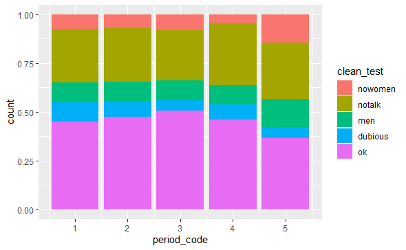

```r
ggplot(bechdel_short, aes(x = period_code, fill = clean_test)) +
  geom_bar(position = "fill")
```

### Relationship between clean_test and budget_2013

- Films that pass the Bechdel Test tend to have slightly lower budgets than those that don’t - particularly those that fewer than 2 women, or where women don’t talk to each other

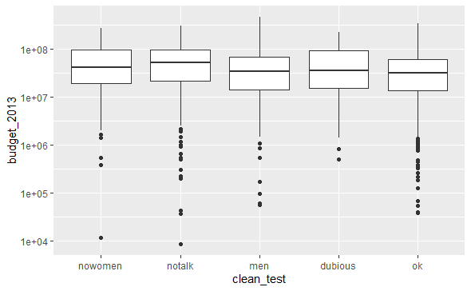

```r
ggplot(bechdel_short, aes(x = clean_test, y = budget_2013)) +
  geom_boxplot() +
  scale_y_log10()
```

### Relationship between clean_test and domgross_2013

- There doesn’t appear to be obvious differences between BT categories and domestic gross in 2013 currency

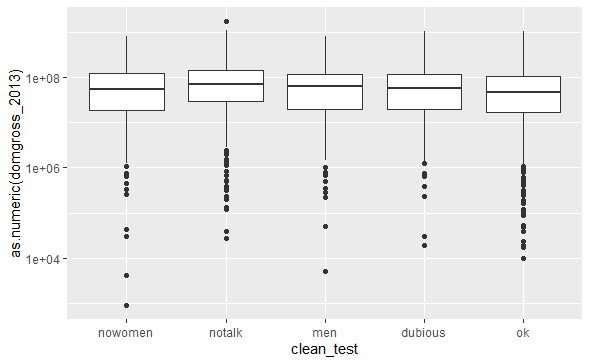

```r
ggplot(bechdel_short, aes(x = clean_test, y = as.numeric(domgross_2013))) +
  geom_boxplot() +
  scale_y_log10()
```

### Relationship between clean_test and intgross_2013

- There doesn’t appear to be obvious differences between BT categories and international gross in 2013 currency

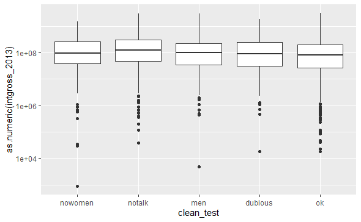

```r
ggplot(bechdel_short, aes(x = clean_test, y = as.numeric(intgross_2013))) +
  geom_boxplot() +
  scale_y_log10()
```

### Relationship between clean_test and rated (where rated is PG, PG-13, or R)

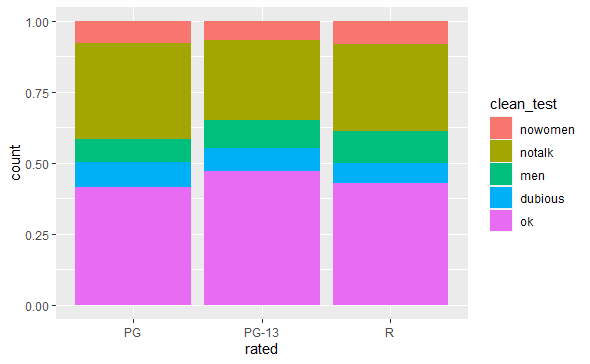

```r
bechdel_short_rated <- bechdel_short %>%
  filter(rated %in% c("PG", "PG-13", "R"))

ggplot(bechdel_short_rated, aes(x = rated, fill = clean_test)) +
  geom_bar(position = "fill")
```

### Relationship between clean_test and metascore

- There is no clear relationship between `clean_test` and `metascore`

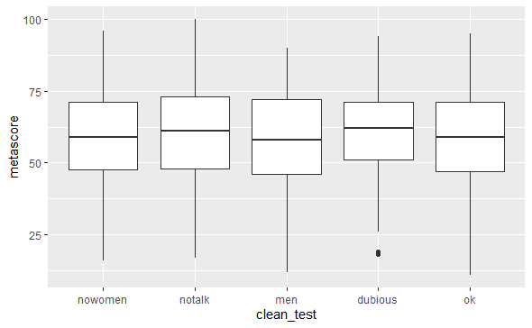

```r
ggplot(bechdel_short, aes(x = clean_test, y = metascore)) +
  geom_boxplot()
```

#### Relationship between clean_test and imdb_rating

- There some evidence that films that pass or almost pass (“dubious”) the Bechdel Test have a lower imdb rating

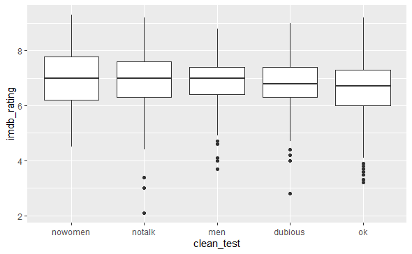

```r
ggplot(bechdel_short, aes(x = clean_test, y = imdb_rating)) +
  geom_boxplot()
```

### Use of the genre variable

- This variable needs further cleaning before it can be used in analysis
- The column contains multiple genres separated by commas
- Max number of genres = 3

```r
bechdel_short_genres <- bechdel_short %>%
  group_by(genre) %>%
  summarize(count = n())

bechdel_short_genres$commas <- str_count(bechdel_short_genres$genre, pattern = ",")

bechdel_short_genres %>%
  group_by(commas) %>%
  summarize(max(commas))
```

|  | commas | max(commas) |
| --- | --- | --- |
| 1 | 0 | 0 |
| 2 | 1 | 1 |
| 3 | 2 | 2 |
| 4 | NA | NA |

```r
bechdel_short_genres
```

| genre | count | commas |
| --- | --- | --- |
| Action | 2 | 0 |
| Action, Adventure | 6 | 1 |
| Action, Adventure, Comedy | 18 | 2 |
| Action, Adventure, Crime | 9 | 2 |
| Action, Adventure, Drama | 19 | 2 |
| Action, Adventure, Family | 7 | 2 |
| Action, Adventure, Fantasy | 41 | 2 |
| Action, Adventure, Horror | 2 | 2 |
| Action, Adventure, Mystery | 4 | 2 |
| Action, Adventure, Romance | 1 | 2 |

[output cut: 262 more lines]

### The relationship between year, imdb_rating and Bechdel test

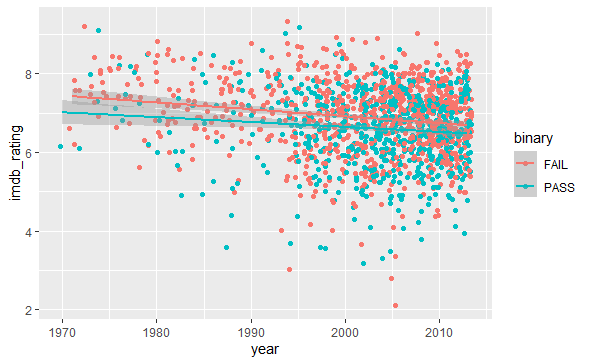

```r
ggplot(bechdel_short, aes(x = year, y = imdb_rating, color = binary)) +
  geom_point(position = "jitter") +
  geom_smooth(method = "lm")
```

### Split genres into columns

- To compare relationships between genres, each genre observation (which can contain multiple genres) has been split into a separate observation
- This means that some films are contained in the table multiple times, however the maximum number of genres for any given film is 3. As a result, I don’t expect this to result in significant bias

```r
# Split genre into 3 columns
bechdel_genre_split <- separate(bechdel_short, 'genre',
                                paste('genre', 1:3, sep="_"),
                                sep=",", extra = "warn")
```

```
Expected 3 pieces. Missing pieces filled with `NA` in 560 rows [11, 12, 14, 16, 25, 30, 32, 35, 36, 38, 40, 43, 45, 48, 53, 65, 66, 67, 68, 69, ...].
```

```r
# Create a separate dataframe for genre_1
genre_1 <- bechdel_genre_split %>%
  select(-genre_2, -genre_3) %>%
  mutate(genre = str_trim(genre_1, side = "both")) %>%
  select(-genre_1)

genre_1
```

| year | title | clean_test | binary | budget_2013 | domgross_2013 | intgross_2013 | period_code | decade_code | rated | metascore | imdb_rating | genre |
| --- | --- | --- | --- | --- | --- | --- | --- | --- | --- | --- | --- | --- |
| 2013 | 21 &amp; Over | notalk | FAIL | 13000000 | 25682380 | 42195766 | 1 | 1 | NA | NA | NA | NA |
| 2012 | Dredd 3D | ok | PASS | 45658735 | 13611086 | 41467257 | 1 | 1 | NA | NA | NA | NA |
| 2013 | 12 Years a Slave | notalk | FAIL | 20000000 | 53107035 | 158607035 | 1 | 1 | R | 97 | 8.3 | Biography |
| 2013 | 2 Guns | notalk | FAIL | 61000000 | 75612460 | 132493015 | 1 | 1 | R | 55 | 6.8 | Action |
| 2013 | 42 | men | FAIL | 40000000 | 95020213 | 95020213 | 1 | 1 | PG-13 | 62 | 7.6 | Biography |
| 2013 | 47 Ronin | men | FAIL | 225000000 | 38362475 | 145803842 | 1 | 1 | PG-13 | 29 | 6.6 | Action |
| 2013 | A Good Day to Die Hard | notalk | FAIL | 92000000 | 67349198 | 304249198 | 1 | 1 | R | 28 | 5.4 | Action |
| 2013 | About Time | ok | PASS | 12000000 | 15323921 | 87324746 | 1 | 1 | R | 55 | 7.8 | Drama |
| 2013 | Admission | ok | PASS | 13000000 | 18007317 | 18007317 | 1 | 1 | PG-13 | 48 | 5.7 | Comedy |
| 2013 | After Earth | notalk | FAIL | 130000000 | 60522097 | 244373198 | 1 | 1 | PG-13 | 33 | 5.0 | Action |

[output cut: 990 more lines]

```r
# Create a separate dataframe for genre_2
genre_2 <- bechdel_genre_split %>%
  select(-genre_1, -genre_3) %>%
  mutate(genre = str_trim(genre_2, side = "both")) %>%
  select(-genre_2)

# Create a separate dataframe for genre_3
genre_3 <- bechdel_genre_split %>%
  select(-genre_1, -genre_2) %>%
  mutate(genre = str_trim(genre_3, side = "both")) %>%
  select(-genre_3)

# All tables combined
all_genres <- rbind.data.frame(genre_1, genre_2, genre_3)

all_genres
```

| year | title | clean_test | binary | budget_2013 | domgross_2013 | intgross_2013 | period_code | decade_code | rated | metascore | imdb_rating | genre |
| --- | --- | --- | --- | --- | --- | --- | --- | --- | --- | --- | --- | --- |
| 2013 | 21 &amp; Over | notalk | FAIL | 13000000 | 25682380 | 42195766 | 1 | 1 | NA | NA | NA | NA |
| 2012 | Dredd 3D | ok | PASS | 45658735 | 13611086 | 41467257 | 1 | 1 | NA | NA | NA | NA |
| 2013 | 12 Years a Slave | notalk | FAIL | 20000000 | 53107035 | 158607035 | 1 | 1 | R | 97 | 8.3 | Biography |
| 2013 | 2 Guns | notalk | FAIL | 61000000 | 75612460 | 132493015 | 1 | 1 | R | 55 | 6.8 | Action |
| 2013 | 42 | men | FAIL | 40000000 | 95020213 | 95020213 | 1 | 1 | PG-13 | 62 | 7.6 | Biography |
| 2013 | 47 Ronin | men | FAIL | 225000000 | 38362475 | 145803842 | 1 | 1 | PG-13 | 29 | 6.6 | Action |
| 2013 | A Good Day to Die Hard | notalk | FAIL | 92000000 | 67349198 | 304249198 | 1 | 1 | R | 28 | 5.4 | Action |
| 2013 | About Time | ok | PASS | 12000000 | 15323921 | 87324746 | 1 | 1 | R | 55 | 7.8 | Drama |
| 2013 | Admission | ok | PASS | 13000000 | 18007317 | 18007317 | 1 | 1 | PG-13 | 48 | 5.7 | Comedy |
| 2013 | After Earth | notalk | FAIL | 130000000 | 60522097 | 244373198 | 1 | 1 | PG-13 | 33 | 5.0 | Action |

[output cut: 990 more lines]

```r
# Calculate the max, min and median rating by genre, by pass/fail
genre_data_all <- all_genres %>%
  group_by(genre) %>%
  summarize(max_rating = max(imdb_rating),
            min_rating = min(imdb_rating),
            med_rating = median(imdb_rating),
            avg_rating = mean(imdb_rating)) %>%
  arrange(desc(avg_rating)) %>%
  mutate(genre = factor(genre, levels = genre))

genre_data_pass <- all_genres %>%
  group_by(genre, binary) %>%
  summarize(max_rating = max(imdb_rating),
            min_rating = min(imdb_rating),
            med_rating = median(imdb_rating),
            avg_rating = mean(imdb_rating)) %>%
  filter(binary == "PASS") %>%
  arrange(desc(avg_rating))
genre_data_fail <- all_genres %>%
  group_by(genre, binary) %>%
  summarize(max_rating = max(imdb_rating),
            min_rating = min(imdb_rating),
            med_rating = median(imdb_rating),
            avg_rating = mean(imdb_rating)) %>%
  filter(binary == "FAIL") %>%
  arrange(desc(avg_rating))
```

```r
base_plot <- ggplot(genre_data_all, aes(x = genre)) +
  geom_segment(aes(x = genre,
                   xend = genre,
                   y = min_rating,
                   yend = max_rating),
               color = "azure3") +
  geom_point(aes(x = genre, y = min_rating),
             color = "firebrick3", size = 3) +
  geom_point(aes(x = genre, y = max_rating),
             color = "aquamarine4", size = 3) +
  theme(axis.text.x = element_text(angle = 90, vjust = 0.25, hjust = 1)) +
  ylab("Minimum and Maximum IMDB rating") +
  xlab("Genre")

#base_plot

pass_plot <- ggplot(genre_data_pass, aes(x = genre, y = avg_rating)) +
  geom_line(aes(group = 1), color = "lightseagreen")

base_plot %+% pass_plot
```

```
Error: Can't add `pass_plot` to a ggplot object.
Run `rlang::last_error()` to see where the error occurred.
```

```r
# Calculate the max, min and median rating by genre, by pass/fail
genre_data_chart <- all_genres %>%
  group_by(genre) %>%
  filter(genre != "NA") %>%
  summarize(max_rating = max(imdb_rating),
            min_rating = min(imdb_rating),
            avg_pass_rating = mean(imdb_rating[binary == "PASS"]),
            avg_fail_rating = mean(imdb_rating[binary == "FAIL"]),
            med_pass_rating = median(imdb_rating[binary == "PASS"]),
            med_fail_rating = median(imdb_rating[binary == "FAIL"]),
            avg_rating = mean(imdb_rating),
            med_rating = median(imdb_rating)) %>%
  arrange(desc(avg_rating)) %>%
  mutate(genre = factor(genre, levels = genre))


genre_data_chart
```

| genre | max_rating | min_rating | avg_pass_rating | avg_fail_rating | med_pass_rating | med_fail_rating | avg_rating | med_rating |
| --- | --- | --- | --- | --- | --- | --- | --- | --- |
| Documentary | 8.0 | 7.2 | 7.200000 | 7.533333 | 7.20 | 7.40 | 7.450000 | 7.30 |
| Biography | 8.8 | 6.0 | 7.248485 | 7.559091 | 7.20 | 7.70 | 7.425974 | 7.50 |
| History | 8.6 | 5.7 | 7.229412 | 7.378125 | 7.30 | 7.60 | 7.326531 | 7.50 |
| War | 8.6 | 5.5 | 7.157143 | 7.359091 | 7.20 | 7.50 | 7.310345 | 7.40 |
| Sport | 8.3 | 5.6 | 6.641667 | 7.356250 | 6.55 | 7.60 | 7.050000 | 7.10 |
| Drama | 9.3 | 3.2 | 6.881319 | 7.182667 | 7.00 | 7.30 | 7.034235 | 7.10 |
| Animation | 8.5 | 4.5 | 7.005882 | 6.972973 | 7.15 | 7.00 | 6.983333 | 7.05 |
| Crime | 9.3 | 3.0 | 6.825641 | 6.997238 | 6.70 | 7.00 | 6.945560 | 6.90 |
| Musical | 8.0 | 5.7 | 6.807692 | 7.125000 | 6.90 | 7.30 | 6.928571 | 7.10 |
| Romance | 9.2 | 4.8 | 6.735294 | 6.879412 | 6.80 | 6.90 | 6.797059 | 6.80 |

[output cut: 11 more lines]

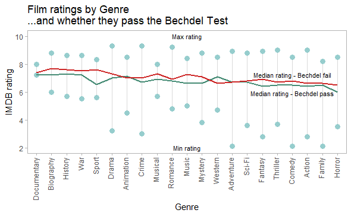

```r
genre_chart <- ggplot(genre_data_chart, aes(x = genre)) +
  # Create the line plots
  geom_segment(aes(x = genre,
                   xend = genre,
                   y = min_rating,
                   yend = max_rating),
               color = "gray85") +
  # Add a point for min rating
  geom_point(aes(x = genre, y = min_rating),
             color = "paleturquoise3", size = 3) +
  # Add a point for max rating
  geom_point(aes(x = genre, y = max_rating),
             color = "paleturquoise3", size = 3) +
  # Add a line for the median rating for BT pass films
  geom_line(aes(y = med_pass_rating, group = 1),
            color = "aquamarine4", size = 1) +
  # Add a line for the median rating for BT fail films
  geom_line(aes(y = med_fail_rating, group = 1),
            color = "firebrick3", size = 1) +

  # Set light theme
  theme_light() +
  # Rotate x axis labels 90 degrees
  theme(axis.text.x = element_text(angle = 90, vjust = 0.25, hjust = 1)) +
  # Remove gridlines
  theme(panel.grid.major = element_blank()) +
  theme(panel.grid.minor = element_blank()) +
  # Add labels for x and y axis
  labs(x = "Genre", y = "IMDB rating",
       title = "Film ratings by Genre \n...and whether they pass the Bechdel Test") +
  # Add labels for min and max ratings
  annotate("text", x = "Music", y = 10,
           label = "Max rating", size = 3) +
  annotate("text", x = "Music", y = 2,
           label = "Min rating", size = 3) +
  # Add labels for median ratings for BT pass and fail films
  annotate("text", x = "Comedy", y = 7.25,
           label = "Median rating - Bechdel fail",
           size = 3) +
    annotate("text", x = "Comedy", y = 5.9,
           label = "Median rating - Bechdel pass",
           size = 3)

genre_chart

ggsave("tidytues_bechdel.png")
```